# Challenge 4

Author

Hannah Pawig

# Challenge

## 1. Creating data set of median home prices

**Here is the code.**

```r
#resources:
# median house price LA: https://www.zillow.com/home-values/12447/los-angeles-ca/
# median house price SD: https://www.zillow.com/home-values/54296/san-diego-ca/
# median house price Sac: https://www.zillow.com/home-values/20288/sacramento-ca/
# median house price SF: https://www.zillow.com/home-values/20330/san-francisco-ca/
house_prices_CA <- data.frame(metro_area = c(
                                         'Sacramento', 'Sacramento',
                                         'Sacramento', 'Sacramento',
                                         'LosAngeles', 'LosAngeles',
                                         'LosAngeles', 'LosAngeles',
                                         'SanDiego', 'SanDiego',
                                         'SanDiego', 'SanDiego',
                                         'SanFrancisco', 'SanFrancisco',
                                         'SanFrancisco', 'SanFrancisco'),
                              year = c('2015', '2016','2017','2018',
                                       '2015', '2016', '2017', '2018',
                                       '2015', '2016','2017','2018',
                                       '2015', '2016','2017','2018'),
                              avg_house_price = c(245447, 272402, 300190, 325171, #LA
                                                   562073, 605462, 647424, 700455, #SAC
                                                   497316, 529688, 567405, 611114, #SD
                                                   1109257, 1190377,
                                                   1227453, 1358550 #SF
                                                   )) |>
  mutate(year = as.numeric(year))
```

## 2. Joining home prices dataset with avocados dataset

**Here is the code.**

```r
# resource: join by multiple columns
# https://www.statology.org/dplyr-join-on-multiple-columns/
avocados_CA <- avocados_metro |>
  filter(metro_area %in% c('LosAngeles', 'Sacramento',
                            'SanDiego', 'SanFrancisco')) |>
  rename(avg_avocado_price = average_price)

CA_houses_avocados <- avocados_CA |>
  left_join(house_prices_CA, by = c("metro_area" = "metro_area", "year" = "year")) |>
  select(metro_area, year, total_volume, avg_avocado_price, avg_house_price) |>
  group_by(metro_area, year) |>
  summarise(avg_avocado_price_yearly = round(mean(avg_avocado_price), digits = 2),
            avg_avocado_volume_yearly = round(mean(total_volume), digits = 2),
            avg_house_price = mean(avg_house_price)
            )
```

## 3. Plotting annual avocado price vs. average house prices!

**Here is the code.**

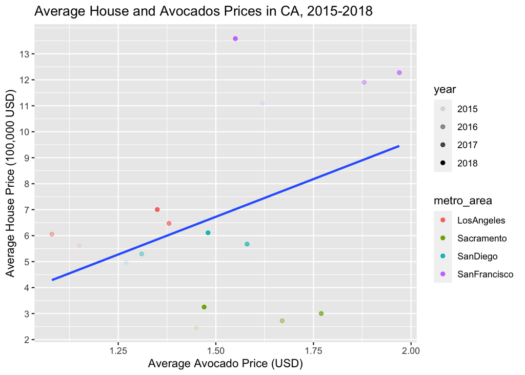

```r
#scatter plot
CA_houses_avocados |>
  ggplot(mapping = aes(x = avg_avocado_price_yearly,
                       y = (avg_house_price/100000))) +
  geom_point(aes(color = metro_area,
                 alpha = year)) +
  geom_smooth(method = 'lm', se = FALSE) +
  scale_y_continuous(breaks = seq(from = 0, to = 13, by = 1)) +
  labs(x = "Average Avocado Price (USD)",
       y = "Average House Price (100,000 USD)",
       title = "Average House and Avocados Prices in CA, 2015-2018")
```

**Here is the code.**

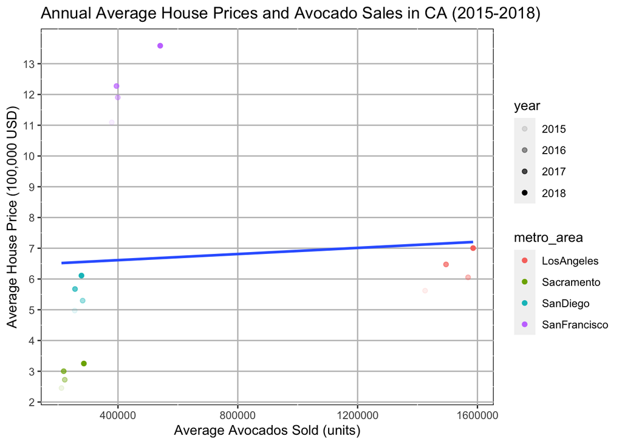

```r
#resource: http://www.sthda.com/english/wiki/ggplot2-scatter-plots-quick-start-guide-r-software-and-data-visualization


# resource for changing plot background color
# https://www.r-bloggers.com/2022/07/how-to-change-background-color-in-ggplot2-3/
CA_houses_avocados |>
  ggplot(mapping = aes(x = avg_avocado_volume_yearly,
                       y = (avg_house_price/100000))) +
  geom_point(aes(color = metro_area,
                  alpha = year)) + #unsure how to make 2015 alpha val less transparent
  theme(panel.background = element_rect(fill = 'white', color = 'black'),
        panel.grid.major = element_line(color = 'grey')) +
  geom_smooth(method = 'lm', se = FALSE) +
  scale_y_continuous(breaks = seq(from = 0, to = 13, by = 1)) +
  labs(x = "Average Avocados Sold (units)",
       y = "Average House Price (100,000 USD)",
       title = "Annual Average House Prices and Avocado Sales in CA (2015-2018)")
```

*A joke in the media is that Millennials can’t afford houses, because they spend all their money buying avocado toast. Let’s use this dataset to address that claim.*

> From the scatter plot of average annual avocado prices and average annual house prices (annual averages from 2015-2018) in California above, I don’t believe that there is a relationship between house prices and avocado prices. As the average avocado price increases, the annual average house price doesn’t necessarily increase as well. This is evident where average avocado prices in Sacramento were higher than those of Los Angeles’ avocado prices, yet Sacramento’s house prices were lower than those of Los Angeles’. In a visual sense, not all of the points are clustered around the linear regression line; if the points were all clustered or mostly clustered with a few outliers, then there could be a possibility of a relationship between the two average prices.

> In the second plot of annual average house prices and average avocados sold, we can observe that the linear regression line is a poor fit for the averages in each of the 4 California reasons. Furthermore, since there is no clear linear relationship between the average number of avocados sold in a year and average house prices, no matter what California region we’re looking at.